# TO-DO:

- explain the rationale for the choice of certain sumstats

# Introduction

This project applies Structural Equation Modelling method (SEM) on the summary statistics of large GWAS on T2D, CAD, stroke, Glycemic traits - fasting glucose, fasting insulin, Glucose 2hr after challenge, insulin fold change.

The datasets used in the analyses:

[output not shown]

8 columns are chosen in this order from the initial summary datasets: A1, A2, Beta, StdErr, P-value, Neff (or effect allele frequency if applicable), CHR:BP, and MAF. For the datasets with only CHR:BP as identity for a variant, rsIDs are inferred by mapping CHR:BP to that in the LD reference file. If A1 and A2 in summary statistics data are the same as A2 and A1 in reference SNP set, then the reversal of beta direction is executed through the `maptoLDhm3.sh` script. Ultimately, about 1 million SNPs are retained for each summary statistics dataset.

# Results

## Population prevalence’s trivial influence on estimated genetic correlation of binary traits - T2D, stroke, CAD

Prevalence is calculated in Europe:

- CAD: [Globally, it was estimated that in 2020, 244.1 million people were living with ischemic heart disease (IHD), and it was more prevalent in males than in females (141.0 and 103.1 million people, respectively).](https://www.heart.org/-/media/PHD-Files-2/Science-News/2/2022-Heart-and-Stroke-Stat-Update/2022-Stat-Update-factsheet-GIobal-Burden-of-Disease.pdf) => 0.031131
- Stroke:
  - Estimate 1: [Truelsen et. al 2006, Stroke incidence and prevalence in Europe: a review of available data](https://onlinelibrary.wiley.com/doi/10.1111/j.1468-1331.2006.01138.x#b28). With WHO estimates of Europeans’ stroke incidence in 2000, projections are made of stroke incidence rate per year up until 2025, with stable rate, or increased or decreased 2% every 5 years. If the stroke rate is unchanged from 2000, it’s estimated that 1.5 million Europeans suffered from stroke in 2025. The countries included in this analyses are current EU member countries, with the addition of UK, Iceland, Norway, and Switzerland. The total population of these countries in 2025 is estimated to be 501,044,143 people. This translates to a rate of 0.00299.
  - Estimate 2: [Wafa et. al 2020, Burden of Stroke in Europe: Thirty-Year Projections of Incidence, Prevalence, Deaths, and Disability-Adjusted Life Years](https://www.ahajournals.org/doi/10.1161/STROKEAHA.120.029606). Table: Changes in Population Count and Stroke Incidence, Prevalence, Deaths, and DALYs in the EU Between 2017 and 2047 => take the estimates of 2027: 0.0202935.
- T2D:
  - The paper on T2D by Manhajan et. al 2022 mentioned that approximately 392 million individuals suffer from T2D in 2015, when world population is at 7,426,597,536 people. => 0.052783
  - Based on the factsheet by AHA above, the rate translates to 0.06024 in 2020.

- run 1: 0.052783 T2D and 0.00299 stroke
- run 2: 0.052783 T2D and 0.0202935 stroke
- run 3: 0.06024 T2D and 0.0202935 stroke
- run 4: 0.06024 T2D and 0.00299 stroke

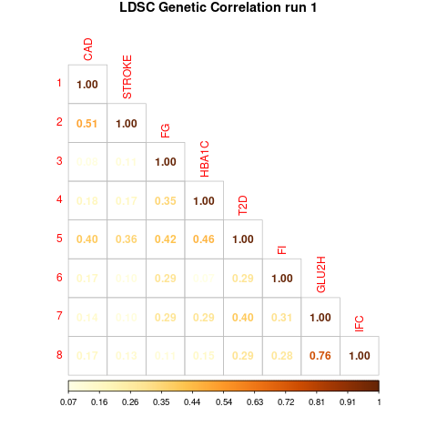

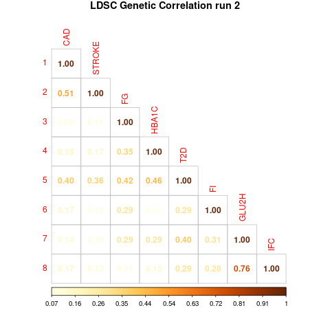

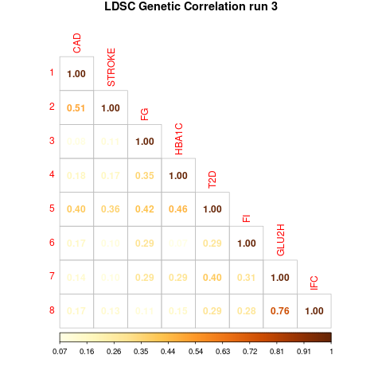

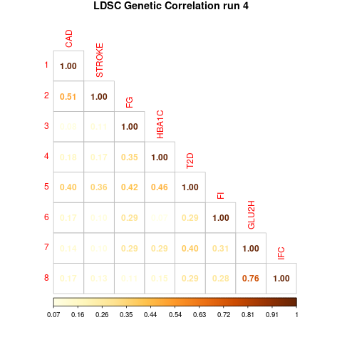